# Capitulo 3

## Resolver integrales entre $0$ e $\infty$

Si $\theta = \int_{0}^{\infty}g(x)dx$ podemos hacer el cambio de variable:

$$\begin{gather}
y = \frac{1}{x+1} \\
dy = \frac{-dx}{(x+1)^{2}}=-y^{2}dx
\end{gather}$$

Y obtenemos la nueva integral:

$$\begin{aligned}
\theta &=\int_{0}^{\infty}g(x)dx \\
&= \int_{1}^{0}\frac{g(\frac{1}{y}-1)}{-y^2}dy \\
&= \int_{0}^{1}\frac{g(\frac{1}{y}-1)}{y^2}dy \\
&= \int_{0}^{1}h(y)dy
\end{aligned}$$

Donde $h(y)=\frac{g(\frac{1}{y}-1)}{y^2}$

- $\int_{0}^{\infty}e^{-x}dx$

$$\begin{aligned}
\theta &= \int_{0}^{\infty}e^{-x}dx \\
&= -\int_{0}^{-\infty}e^{u}du \\
&=\int_{-\infty}^{0}e^{u}du \\
&= e^{u}\Big|_{-\infty}^{0} \\
&= e^{0}-e^{-\infty} \\
&= 1 - 0 \\
&= 1
\end{aligned}$$

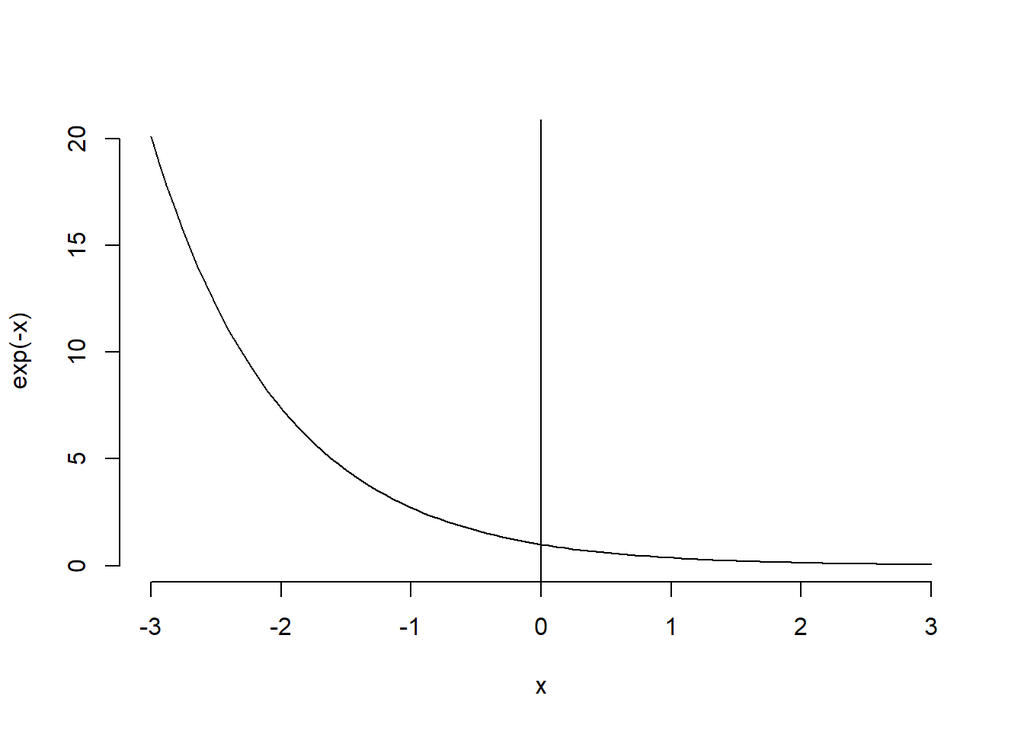

```r
curve(exp(-x), frame = FALSE, from = -3, to = 3)
abline(v = 0)
```

```r
n <- 1000
g <- function(x) exp(-x)
h <- function(y) g((1 / y) - 1)/(y^2)
u <- runif(n = n)
res <- mean(h(u))
res
```

```
## [1] 0.9867224
```

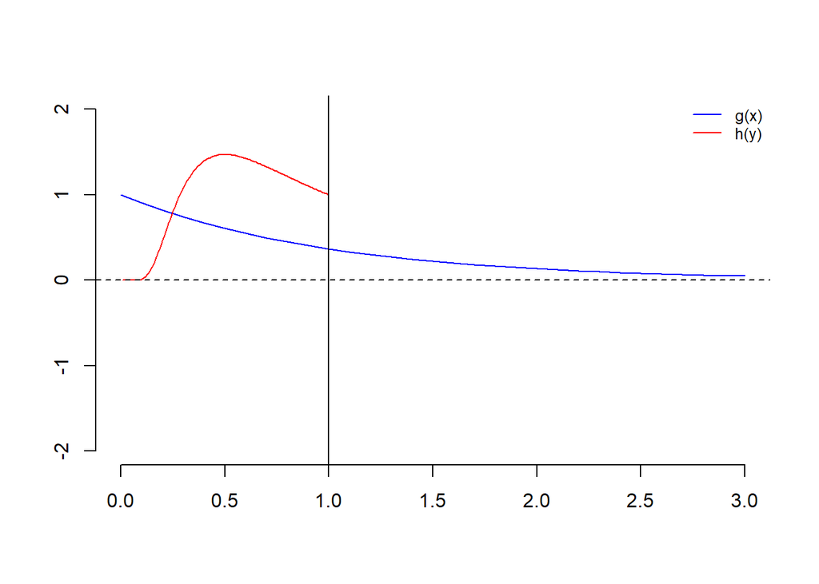

```r
vab <- seq(0, 3, 0.1)
v01 <- seq(0, 1, 0.01)

plot(x = vab, y = g(vab), type = "l", col = "blue", xlab = "", ylab = "",
     ylim = c(-2, 2), xlim = c(0, 3), frame = FALSE)
lines(x = v01, y = h(v01), type = "l", col = "red")
abline(h = 0, col = "black", lty = 2)
legend("topright", legend = c("g(x)", "h(y)"), lty = c(1, 1),
       col = c("blue", "red"), bg = "transparent", bty = "n", cex = 0.8)
abline(v = 1)
```

- Si la función es par, la integral en el rango $(-\infty, \infty)$ es dos veces la integral en el rango $(0, \infty)$
- Si la función no es par, se debe partir el rango $(-\infty, \infty)$ en:
- $(0, \infty)$ donde se hace el cambio de variable para $(0, 1)$
- $(-\infty, 0)$ donde se hace el cambio de signo de $g(-x)$ para hacer el cambio de límites $(0, \infty)$ y luego hacer el reemplazo de límites a $(0, 1)$

## Integrales multidimensionales

```r
fun <- function(x) exp(-x[1] - x[2])
k <- 5
U <- matrix(runif(n = 2*k), ncol = 2)
mean(apply(X = U, MARGIN = 1, FUN = fun))

k <- c(10, 20, 50, 100, 200, 500, 1000, 2000, 5000, 10000)

multi <- function(n){
    fun <- function(x) exp(-x[1] - x[2])
    i = 1
    for (i in 1:length(k)) {
        U <- matrix(runif(n = 2*k[i]), ncol = 2)
        resultados[i,1] <- k[i]
        resultados[i,2] <- mean(apply(X = U, MARGIN = 1, FUN = fun))
        i <- i + 1
    }
    return(resultados)
}

res <- multi(1000)

plot(x = res[,1], y = res[,2], type = "b", xlab = "k", ylab = "resultado")

?persp()
```

```r
fun <- function(x) exp(x[1] * x[2]^2)
k <- 20
U <- matrix(runif(n = 2*k), ncol = 2)
mean(apply(X = U, MARGIN = 1, FUN = fun))

k <- c(10, 20, 50, 100, 200, 500, 1000, 2000, 5000, 10000)

multi <- function(n){
    fun <- function(x) exp(-x[1] - x[2])
    i = 1
    for (i in 1:length(k)) {
        U <- matrix(runif(n = 2*k[i]), ncol = 2)
        resultados[i,1] <- k[i]
        resultados[i,2] <- mean(apply(X = U, MARGIN = 1, FUN = fun))
        i <- i + 1
    }
    return(resultados)
}

res <- multi(1000)

plot(x = res[,1], y = res[,2], type = "b", xlab = "k", ylab = "resultado")

?persp()
```